# Airquality1

GS Kumbhare

09/08/2020

# Airquality

First we load the dataset from r directory.

```r
datasets::airquality
```

[output not shown]

[output cut: 139 more lines]

We first analyse structure of Airquality dataset obtained from r dataset directory.

```r
str(airquality)
```

```
## 'data.frame':    153 obs. of  6 variables:
##  $ Ozone  : int  41 36 12 18 NA 28 23 19 8 NA ...
##  $ Solar.R: int  190 118 149 313 NA NA 299 99 19 194 ...
##  $ Wind   : num  7.4 8 12.6 11.5 14.3 14.9 8.6 13.8 20.1 8.6 ...
##  $ Temp   : int  67 72 74 62 56 66 65 59 61 69 ...
##  $ Month  : int  5 5 5 5 5 5 5 5 5 5 ...
##  $ Day    : int  1 2 3 4 5 6 7 8 9 10 ...
```

We find that there are number of na values in the structure of 153 observations. Let us calculate number of na values in each variables and filter them accordingly.

```r
colSums(is.na(airquality))
```

```
##   Ozone Solar.R    Wind    Temp   Month     Day
##      37       7       0       0       0       0
```

With the above table it can be seen that number of na values or missing values in our dataset.

```r
air= airquality
#Monthly mean to Ozone
for (i in 1:nrow(air)){
  if(is.na(air[i, "Ozone"])){
    air[i,"Ozone"]<- mean(air[which(air[,"Month"]==air[i,"Month"]),"Ozone"],na.rm = TRUE)
  }
}
#Monthly mean to solar. R
for (i in 1:nrow(air)){
  if(is.na(air[i, "Solar.R"])){
    air[i,"Solar.R"]<- mean(air[which(air[,"Month"]==air[i,"Month"]),"Solar.R"],na.rm = TRUE)
  }
}
summary(air)
```

```
##      Ozone           Solar.R           Wind             Temp
##  Min.   :  1.00   Min.   :  7.0   Min.   : 1.700   Min.   :56.00
##  1st Qu.: 21.00   1st Qu.:120.0   1st Qu.: 7.400   1st Qu.:72.00
##  Median : 29.44   Median :194.0   Median : 9.700   Median :79.00
##  Mean   : 40.85   Mean   :185.5   Mean   : 9.958   Mean   :77.88
##  3rd Qu.: 59.12   3rd Qu.:256.0   3rd Qu.:11.500   3rd Qu.:85.00
##  Max.   :168.00   Max.   :334.0   Max.   :20.700   Max.   :97.00
##      Month            Day
##  Min.   :5.000   Min.   : 1.0
##  1st Qu.:6.000   1st Qu.: 8.0
##  Median :7.000   Median :16.0
##  Mean   :6.993   Mean   :15.8
##  3rd Qu.:8.000   3rd Qu.:23.0
##  Max.   :9.000   Max.   :31.0
```

We removed na from the dataset.

### Normalization

Our dataset has varying range. Ozone is in scale of PPM, Solar radiation is in range of PPM, Temp is scale of Farenheit, and wind in scale of km/hr. As our data set has variying range and we normalize the dataset for better fit.

```r
normal<- function(x){
  return((x-min(x))/(max(x)-min(x)))
}
air<- normal(air)
str(air)
```

```
## 'data.frame':    153 obs. of  6 variables:
##  $ Ozone  : num  0.1201 0.1051 0.033 0.0511 0.0679 ...
##  $ Solar.R: num  0.568 0.351 0.444 0.937 0.541 ...
##  $ Wind   : num  0.0192 0.021 0.0348 0.0315 0.0399 ...
##  $ Temp   : num  0.198 0.213 0.219 0.183 0.165 ...
##  $ Month  : num  0.012 0.012 0.012 0.012 0.012 ...
##  $ Day    : num  0 0.003 0.00601 0.00901 0.01201 ...
```

### Libraries

We load required libraries for our regression analysis.

```r
library(ggplot2)
library(dplyr)
library(tidyverse)
library(corrplot)
```

### univariate analysis

Box plot

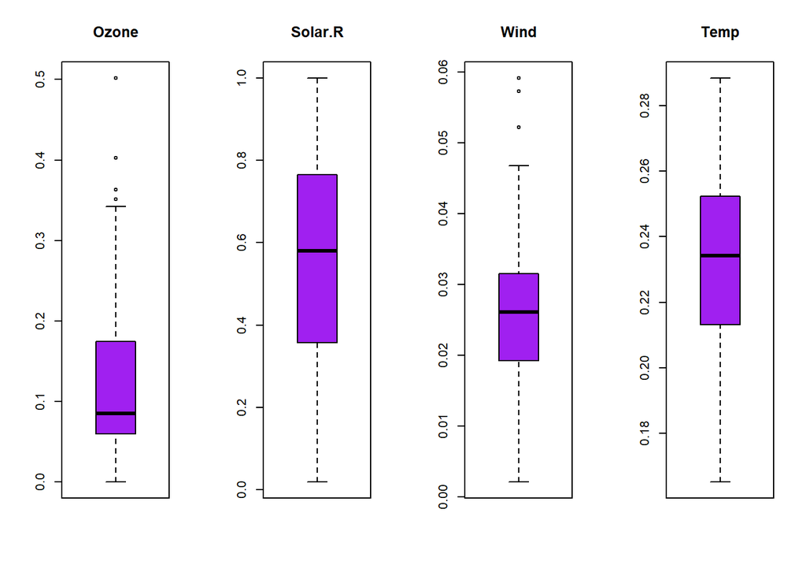

```r
par(mfrow=c(1,4))
for(i in 1:4) {
    boxplot(air[,i], main=names(air)[i],
   col = c("purple"))
}
```

Histogram

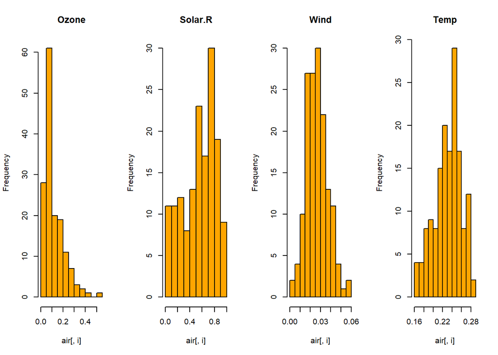

```r
par(mfrow=c(1,4))
for(i in 1:4) {
    hist(air[,i], main=names(air)[i],
   col = c("orange"))
}
```

### Multivariate Analysis

In multi variate analysis we would be using scatter plot to do multivariate analysis our first model is Ozone vs Solar radiation scatter box.

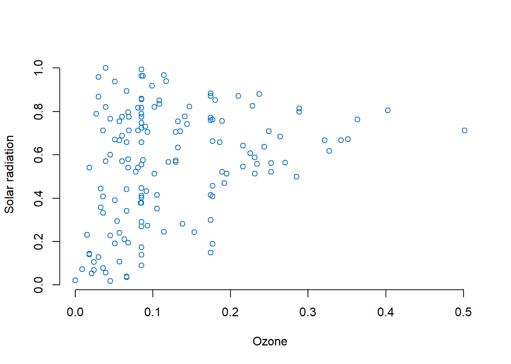

```r
plot(x = air$Ozone, y = air$Solar.R, frame = FALSE,
      xlab = "Ozone", ylab = "Solar radiation",
      col =  "#0073C2FF")
```

Model 2

Ozone vs Wind

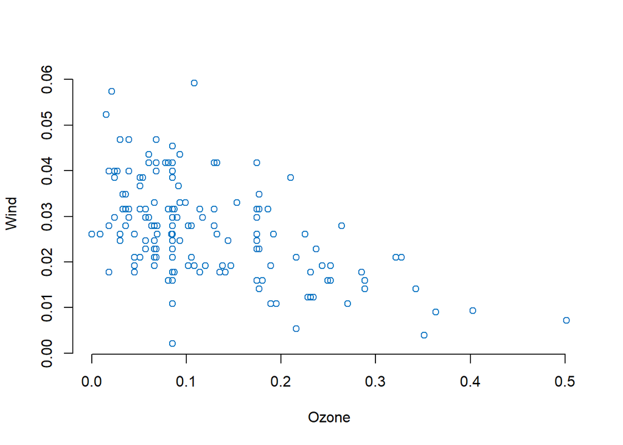

```r
plot(x = air$Ozone, y = air$Wind, frame = FALSE,
      xlab = "Ozone", ylab = "Wind",
       col =  "#0073C2FF")
```

Model 3 Ozone vs Temperature

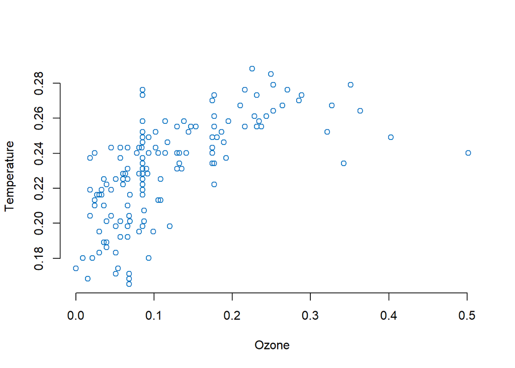

```r
plot(x = air$Ozone, y = air$Temp, frame = FALSE,
      xlab = "Ozone", ylab = "Temperature",
       col =  "#0073C2FF")
```

### Correlation

The following table and plot shows correlation between variables.

```r
cor(air[,1:4])
```

```
##              Ozone     Solar.R        Wind       Temp
## Ozone    1.0000000  0.29280514 -0.51675044  0.6456381
## Solar.R  0.2928051  1.00000000 -0.05237183  0.2619312
## Wind    -0.5167504 -0.05237183  1.00000000 -0.4579879
## Temp     0.6456381  0.26193117 -0.45798788  1.0000000
```

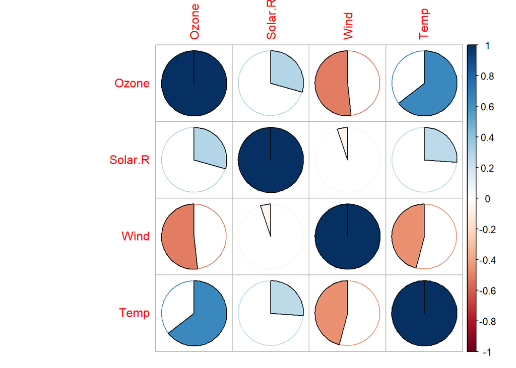

```r
corrplot(cor(air[,1:4]), method = "pie")
```

### Overall Plot

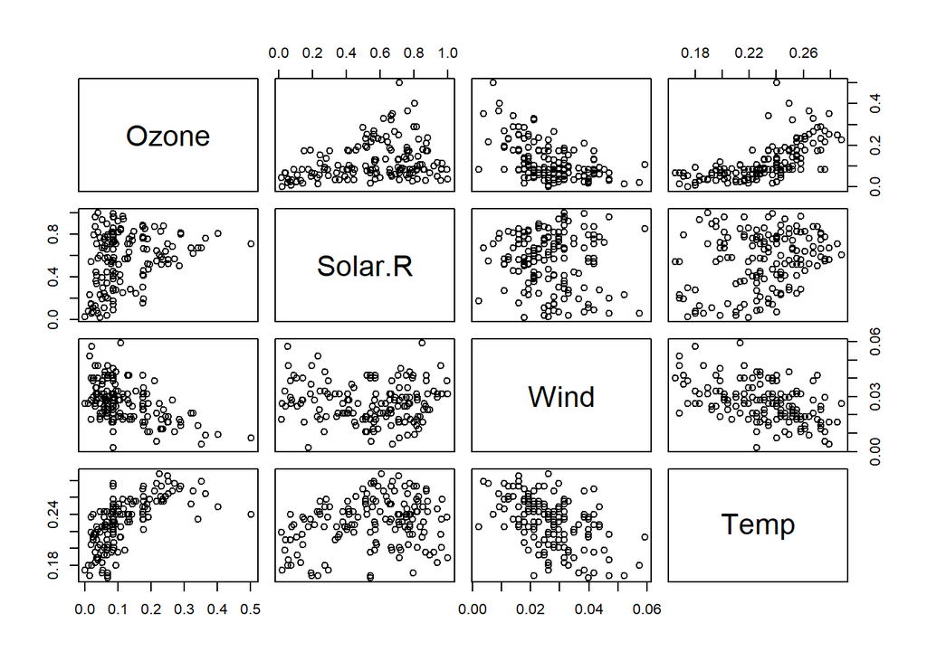

```r
plot(air[,1:4])
```

## Regression analysis

### linear regression

While progressing through linear regression we will make forward selection regression models. Our first model will have Ozone as prediction variable and Solar radiation as predictor variable.

### Model 1 Ozone vs Solar radiation Linear regression

```r
modelLm1<- lm(Ozone~ Solar.R, data = air)
print(modelLm1)
```

```
##
## Call:
## lm(formula = Ozone ~ Solar.R, data = air)
##
## Coefficients:
## (Intercept)      Solar.R
##     0.06509      0.09849
```

From the model above we can see that every single percentage increse in Solar radiation our Ozone increases by 0.098.

```r
summary(modelLm1)
```

```
##
## Call:
## lm(formula = Ozone ~ Solar.R, data = air)
##
## Residuals:
##      Min       1Q   Median       3Q      Max
## -0.12941 -0.06012 -0.02274  0.04524  0.36631
##
## Coefficients:
##             Estimate Std. Error t value Pr(>|t|)
## (Intercept)  0.06509    0.01606   4.054 8.05e-05 ***
## Solar.R      0.09849    0.02617   3.763  0.00024 ***
## ---
## Signif. codes:  0 '***' 0.001 '**' 0.01 '*' 0.05 '.' 0.1 ' ' 1
##
## Residual standard error: 0.08526 on 151 degrees of freedom
## Multiple R-squared:  0.08573,    Adjusted R-squared:  0.07968
## F-statistic: 14.16 on 1 and 151 DF,  p-value: 0.0002398
```

1. Residual is near 0 which means Ozone to Solar radiation residual is symmetrical.
2. The average Solar radiation is 0.065 Units to that of Ozone.
3. Every 1 unit increase in Solar radiation the Ozone increases by 0.098 Unit and vice versa.
4. If we re run the model there can be difference of 0.016 Units of Ozone.
5. Our p value is significantly small thus we can reject null hypothesis.
6. Our residual standard error is 0.085. We can say that percentage rate is 130.76%.
7. R^2 is 0.085 or 8.5% variaance found which is relatively small. Solar radiation is not a strong predictor variable for Ozone.

```r
modelLm2<- lm(Ozone~Wind,data= air)
print(modelLm2)
```

```
##
## Call:
## lm(formula = Ozone ~ Wind, data = air)
##
## Coefficients:
## (Intercept)         Wind
##      0.2364      -4.3410
```

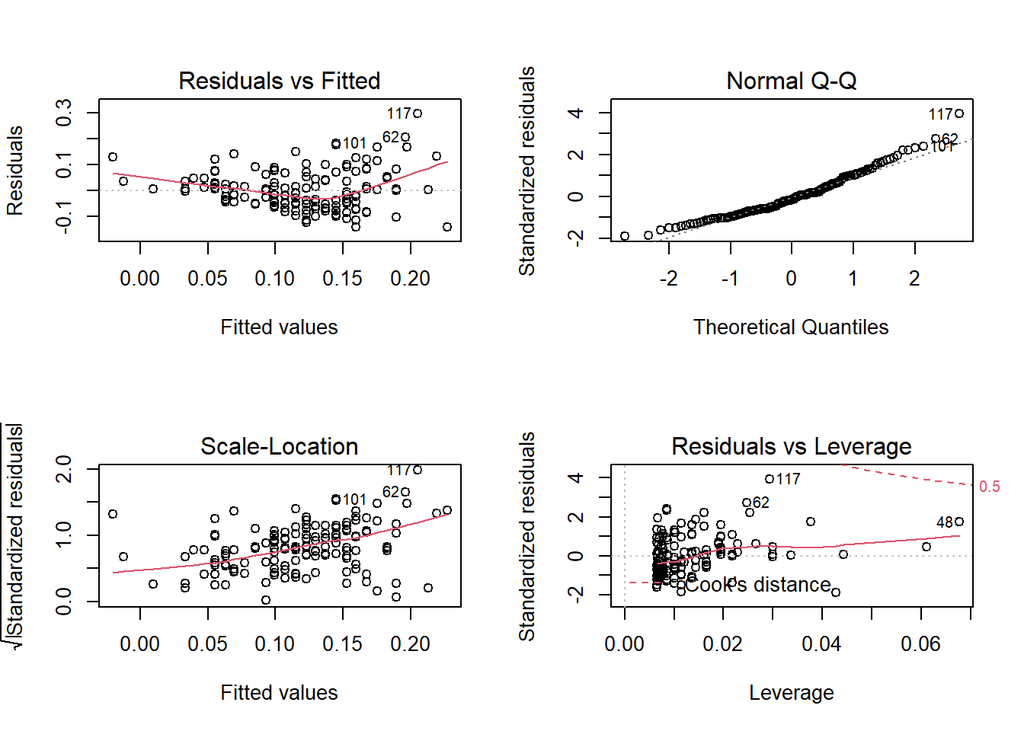

```r
par(mfrow = c(2,2))
plot(modelLm2)
```

```r
summary(modelLm2)
```

```
##
## Call:
## lm(formula = Ozone ~ Wind, data = air)
##
## Residuals:
##      Min       1Q   Median       3Q      Max
## -0.14190 -0.05215 -0.01311  0.04523  0.29634
##
## Coefficients:
##             Estimate Std. Error t value Pr(>|t|)
## (Intercept)  0.23644    0.01691  13.982  < 2e-16 ***
## Wind        -4.34099    0.58528  -7.417 8.03e-12 ***
## ---
## Signif. codes:  0 '***' 0.001 '**' 0.01 '*' 0.05 '.' 0.1 ' ' 1
##
## Residual standard error: 0.07634 on 151 degrees of freedom
## Multiple R-squared:  0.267,  Adjusted R-squared:  0.2622
## F-statistic: 55.01 on 1 and 151 DF,  p-value: 8.034e-12
```

### Model 3 Ozone vs Temperature

```r
modelLm3<- lm(Ozone~Temp,data= air)
print(modelLm3)
```

```
##
## Call:
## lm(formula = Ozone ~ Temp, data = air)
##
## Coefficients:
## (Intercept)         Temp
##     -0.3464       2.0187
```

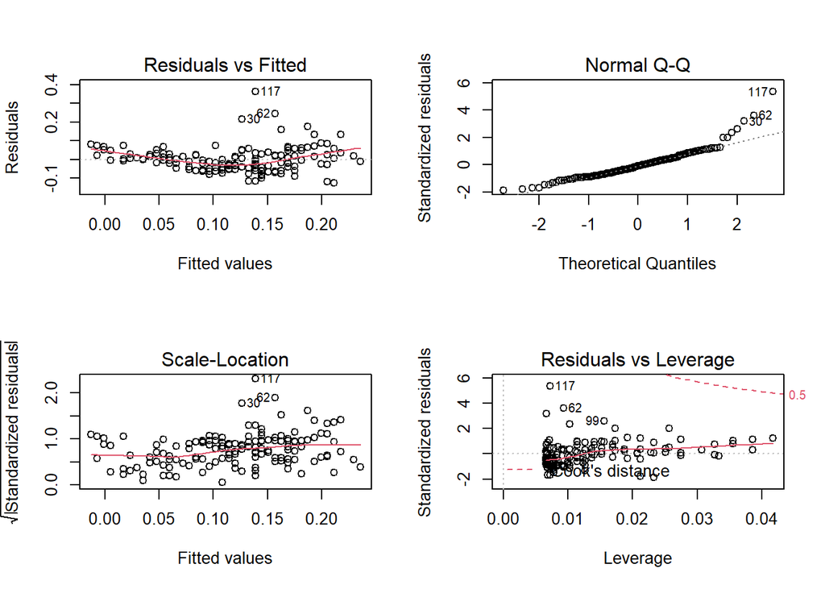

```r
par(mfrow = c(2,2))
plot(modelLm3)
```

```r
summary(modelLm3)
```

```
##
## Call:
## lm(formula = Ozone ~ Temp, data = air)
##
## Residuals:
##      Min       1Q   Median       3Q      Max
## -0.12590 -0.04709 -0.00644  0.03172  0.36293
##
## Coefficients:
##             Estimate Std. Error t value Pr(>|t|)
## (Intercept)  -0.3464     0.0452  -7.664 2.03e-12 ***
## Temp          2.0187     0.1943  10.389  < 2e-16 ***
## ---
## Signif. codes:  0 '***' 0.001 '**' 0.01 '*' 0.05 '.' 0.1 ' ' 1
##
## Residual standard error: 0.06809 on 151 degrees of freedom
## Multiple R-squared:  0.4168, Adjusted R-squared:  0.413
## F-statistic: 107.9 on 1 and 151 DF,  p-value: < 2.2e-16
```

1. Residual is near 0 which means Ozone to Temperature residual is symmetrical.
2. Every 1 unit increase in Temperature the Ozone Increases by 2.018 Unit and vice versa.
3. If we re run the model, standard error difference can be of 0.194 Units of Ozone.
4. Our p value is significantly small thus we can reject null hypothesis.
5. Our residual standard error is 0.068. We can say that percentage rate is 3.38%.
6. R^2 is 0.416 or 41.6% variance found which is relatively bigger than the other predictor. This shows that Temperature is a strong predictor variable for Ozone.

```r
predy <- predict(modelLm3, air, interval="predict", level=.95) + predict(modelLm1, air, interval="predict", level=.95) + predict(modelLm2, air, interval="predict", level=.95)
summary(predy)
```

```
##       fit              lwr                upr
##  Min.   :0.0752   Min.   :-0.38751   Min.   :0.5379
##  1st Qu.:0.2963   1st Qu.:-0.16086   1st Qu.:0.7535
##  Median :0.3668   Median :-0.08861   Median :0.8225
##  Mean   :0.3590   Mean   :-0.09776   Mean   :0.8158
##  3rd Qu.:0.4301   3rd Qu.:-0.02566   3rd Qu.:0.8858
##  Max.   :0.5682   Max.   : 0.10922   Max.   :1.0272
```

```r
conf <- predict(modelLm3, air, interval="confidence", level=.95) + predict(modelLm1, air, interval="confidence", level=.95) + predict(modelLm2, air, interval="confidence", level=.95)

summary(conf)
```

```
##       fit              lwr                upr
##  Min.   :0.0752   Min.   :-0.01359   Min.   :0.1640
##  1st Qu.:0.2963   1st Qu.: 0.24611   1st Qu.:0.3477
##  Median :0.3668   Median : 0.32463   Median :0.4092
##  Mean   :0.3590   Mean   : 0.30904   Mean   :0.4090
##  3rd Qu.:0.4301   3rd Qu.: 0.38108   3rd Qu.:0.4733
##  Max.   :0.5682   Max.   : 0.50251   Max.   :0.6339
```

```r
conf[1]== predy[1]
```

```
## [1] TRUE
```

### Conclusion

Through this Analysis we did regression analysis for different predictors of Ozone. We found that Temperature is fittest predictor of Ozone layer. We learned to analyse different predictor with univariate and bivariate analysis. We learned to build histogram and boxplots for variables. We learned to plot correlation plots.